# Kedir Nasir Omer # Submitted to John Hopskins University # July 4/2022 # Practical Machine Learning Project

# Practical Machine Learning Project

Kedir Nasir Omer

july 09, 2022

## Overview

Using devices such as Jawbone Up, Nike FuelBand, and Fitbit it is now possible to collect a large amount of data about personal activity relatively inexpensively. These type of devices are part of the quantified self movement - a group of enthusiasts who take measurements about themselves regularly to improve their health, to find patterns in their behavior, or because they are tech geeks. One thing that people regularly do is quantify how much of a particular activity they do, but they rarely quantify how well they do it. In this project, your goal will be to use data from accelerometers on the belt, forearm, arm, and dumbell of 6 participants. They were asked to perform barbell lifts correctly and incorrectly in 5 different ways.

The goal of this project is to build a machine learning algorithm to predict activity quality (classe) from activity monitors.

## Set the path and Download csv files

```r
setwd("C:/Personal/coursera-data-science/8-Practical-Machine-Learning/Project")
library(caret)
```

```r
library(ggplot2)
library(randomForest)
#download files from the urls provided
train_url <- "http://d396qusza40orc.cloudfront.net/predmachlearn/pml-training.csv"
download.file(url=train_url, destfile="training.csv")

test_url <- "http://d396qusza40orc.cloudfront.net/predmachlearn/pml-testing.csv"
download.file(url=test_url, destfile="testing.csv")

#read in training and testing data
train <- read.csv("training.csv", na.strings=c("NA","#DIV/0!",""))
test <- read.csv("testing.csv", na.strings=c("NA","#DIV/0!",""))

names(train)
```

```
##   [1] "X"                        "user_name"
##   [3] "raw_timestamp_part_1"     "raw_timestamp_part_2"
##   [5] "cvtd_timestamp"           "new_window"
##   [7] "num_window"               "roll_belt"
##   [9] "pitch_belt"               "yaw_belt"
##  [11] "total_accel_belt"         "kurtosis_roll_belt"
##  [13] "kurtosis_picth_belt"      "kurtosis_yaw_belt"
##  [15] "skewness_roll_belt"       "skewness_roll_belt.1"
##  [17] "skewness_yaw_belt"        "max_roll_belt"
##  [19] "max_picth_belt"           "max_yaw_belt"
##  [21] "min_roll_belt"            "min_pitch_belt"
##  [23] "min_yaw_belt"             "amplitude_roll_belt"
##  [25] "amplitude_pitch_belt"     "amplitude_yaw_belt"
##  [27] "var_total_accel_belt"     "avg_roll_belt"
##  [29] "stddev_roll_belt"         "var_roll_belt"
```

[output cut: 65 more lines]

```r
str(train)
```

```
## 'data.frame':    19622 obs. of  160 variables:
##  $ X                       : int  1 2 3 4 5 6 7 8 9 10 ...
##  $ user_name               : Factor w/ 6 levels "adelmo","carlitos",..: 2 2 2 2 2 2 2 2 2 2 ...
##  $ raw_timestamp_part_1    : int  1323084231 1323084231 1323084231 1323084232 1323084232 1323084232 1323084232 1323084232 1323084232 1323084232 ...
##  $ raw_timestamp_part_2    : int  788290 808298 820366 120339 196328 304277 368296 440390 484323 484434 ...
##  $ cvtd_timestamp          : Factor w/ 20 levels "02/12/2011 13:32",..: 9 9 9 9 9 9 9 9 9 9 ...
##  $ new_window              : Factor w/ 2 levels "no","yes": 1 1 1 1 1 1 1 1 1 1 ...
##  $ num_window              : int  11 11 11 12 12 12 12 12 12 12 ...
##  $ roll_belt               : num  1.41 1.41 1.42 1.48 1.48 1.45 1.42 1.42 1.43 1.45 ...
##  $ pitch_belt              : num  8.07 8.07 8.07 8.05 8.07 8.06 8.09 8.13 8.16 8.17 ...
##  $ yaw_belt                : num  -94.4 -94.4 -94.4 -94.4 -94.4 -94.4 -94.4 -94.4 -94.4 -94.4 ...
##  $ total_accel_belt        : int  3 3 3 3 3 3 3 3 3 3 ...
##  $ kurtosis_roll_belt      : num  NA NA NA NA NA NA NA NA NA NA ...
##  $ kurtosis_picth_belt     : num  NA NA NA NA NA NA NA NA NA NA ...
##  $ kurtosis_yaw_belt       : logi  NA NA NA NA NA NA ...
```

[output cut: 86 more lines]

```r
summary(train)
```

[output not shown]

[output cut: 313 more lines]

```
##  Min.   :-446.00   Min.   :-1280.0   Min.   :-896.0   Min.   :-973.0
##  1st Qu.:-182.00   1st Qu.: -616.0   1st Qu.:   2.0   1st Qu.: 191.0
##  Median : -39.00   Median : -378.0   Median : 591.0   Median : 511.0
##  Mean   : -55.29   Mean   : -312.6   Mean   : 380.1   Mean   : 393.6
##  3rd Qu.:  26.00   3rd Qu.:  -73.0   3rd Qu.: 737.0   3rd Qu.: 653.0
##  Max.   : 291.00   Max.   :  672.0   Max.   :1480.0   Max.   :1090.0
##
##  classe
##  A:5580
##  B:3797
##  C:3422
##  D:3216
##  E:3607
##
##
```

```r
summary(train$classe)
```

```
##    A    B    C    D    E
## 5580 3797 3422 3216 3607
```

## Split training/testing data

Before we do anything, we will set aside a subset of our training data for cross validation (40%).

```r
inTrain <- createDataPartition(y=train$classe, p=0.6, list=FALSE)
myTrain <- train[inTrain, ]
myTest <- train[-inTrain, ]
dim(myTrain)
```

```
## [1] 11776   160
```

```r
dim(myTest)
```

```
## [1] 7846  160
```

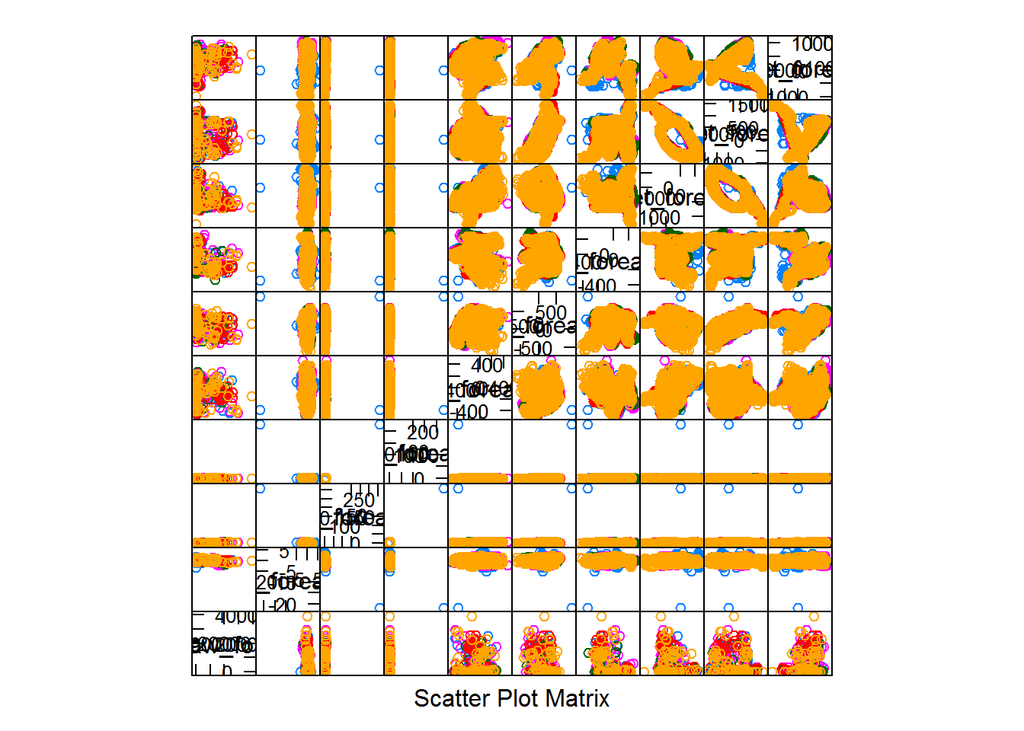

```r
#some exploratory plots
featurePlot(x=train[, 150:159], y = train$classe, plot = 'pairs')
```

## Feature selection

Now we can tranform the data to only include the variables we will need to build our model. We will remove variables with near zero variance, variables with mostly missing data, and variables that are obviously not useful as predictors.

```r
#first we will remove variables with mostly NAs (use threshold of >75%)
mytrain_SUB <- myTrain
for (i in 1:length(myTrain)) {
  if (sum(is.na(myTrain[ , i])) / nrow(myTrain) >= .75) {
    for (j in 1:length(mytrain_SUB)) {
      if (length(grep(names(myTrain[i]), names(mytrain_SUB)[j]))==1) {
        mytrain_SUB <- mytrain_SUB[ , -j]
      }
    }
  }
}

dim(mytrain_SUB)
```

```
## [1] 11776    60
```

```r
#names(mytrain_SUB)

#remove columns that are obviously not predictors
mytrain_SUB2 <- mytrain_SUB[,8:length(mytrain_SUB)]

#remove variables with near zero variance
NZV <- nearZeroVar(mytrain_SUB2, saveMetrics = TRUE)
NZV #all false, none to remove
```

```
##                      freqRatio percentUnique zeroVar   nzv
## roll_belt             1.123077    8.80604620   FALSE FALSE
## pitch_belt            1.059322   13.90115489   FALSE FALSE
## yaw_belt              1.050000   14.52955163   FALSE FALSE
## total_accel_belt      1.067881    0.23777174   FALSE FALSE
## gyros_belt_x          1.038323    1.07846467   FALSE FALSE
## gyros_belt_y          1.128370    0.56046196   FALSE FALSE
## gyros_belt_z          1.024954    1.38417120   FALSE FALSE
## accel_belt_x          1.008114    1.35869565   FALSE FALSE
## accel_belt_y          1.122517    1.12092391   FALSE FALSE
## accel_belt_z          1.069288    2.43716033   FALSE FALSE
## magnet_belt_x         1.013699    2.46263587   FALSE FALSE
## magnet_belt_y         1.027160    2.40319293   FALSE FALSE
## magnet_belt_z         1.071942    3.64300272   FALSE FALSE
## roll_arm             49.357143   19.35292120   FALSE FALSE
## pitch_arm            94.227273   22.52038043   FALSE FALSE
## yaw_arm              30.940299   21.56080163   FALSE FALSE
## total_accel_arm       1.054206    0.56046196   FALSE FALSE
## gyros_arm_x           1.016026    5.25645380   FALSE FALSE
## gyros_arm_y           1.431310    3.06555707   FALSE FALSE
## gyros_arm_z           1.147059    1.98709239   FALSE FALSE
## accel_arm_x           1.038835    6.38586957   FALSE FALSE
## accel_arm_y           1.133858    4.41576087   FALSE FALSE
## accel_arm_z           1.142857    6.46229620   FALSE FALSE
## magnet_arm_x          1.018519   11.16677989   FALSE FALSE
## magnet_arm_y          1.018182    7.22656250   FALSE FALSE
## magnet_arm_z          1.060606   10.54687500   FALSE FALSE
## roll_dumbbell         1.012500   87.58491848   FALSE FALSE
## pitch_dumbbell        2.308642   85.55536685   FALSE FALSE
## yaw_dumbbell          1.012500   87.09239130   FALSE FALSE
## total_accel_dumbbell  1.019162    0.35665761   FALSE FALSE
## gyros_dumbbell_x      1.058333    1.97010870   FALSE FALSE
## gyros_dumbbell_y      1.282913    2.24184783   FALSE FALSE
## gyros_dumbbell_z      1.117978    1.61345109   FALSE FALSE
## accel_dumbbell_x      1.005208    3.41372283   FALSE FALSE
## accel_dumbbell_y      1.062937    3.80434783   FALSE FALSE
## accel_dumbbell_z      1.007143    3.37975543   FALSE FALSE
## magnet_dumbbell_x     1.133929    8.84001359   FALSE FALSE
## magnet_dumbbell_y     1.288660    6.83593750   FALSE FALSE
## magnet_dumbbell_z     1.066116    5.58763587   FALSE FALSE
## roll_forearm         12.571429   14.62296196   FALSE FALSE
## pitch_forearm        55.209302   20.86447011   FALSE FALSE
## yaw_forearm          15.415584   14.05400815   FALSE FALSE
## total_accel_forearm   1.114474    0.55197011   FALSE FALSE
## gyros_forearm_x       1.044304    2.34375000   FALSE FALSE
## gyros_forearm_y       1.008584    6.08016304   FALSE FALSE
## gyros_forearm_z       1.159259    2.40319293   FALSE FALSE
## accel_forearm_x       1.163636    6.58967391   FALSE FALSE
## accel_forearm_y       1.157895    8.21161685   FALSE FALSE
## accel_forearm_z       1.064516    4.61956522   FALSE FALSE
## magnet_forearm_x      1.000000   11.94802989   FALSE FALSE
## magnet_forearm_y      1.387755   15.16644022   FALSE FALSE
## magnet_forearm_z      1.054054   13.31521739   FALSE FALSE
## classe                1.469065    0.04245924   FALSE FALSE
```

```
keep <- names(mytrain_SUB2)
```

## Random Forest Model

I decided to use the random forest model to build my machine learning algorithm as it is appropriate for a classification problem as we have and based on information provided in class lectures this model tends to be more accurate than some other classification models.

```r
#fit model- RANDOM FOREST
set.seed(223)

modFit <- randomForest(classe~., data = mytrain_SUB2)
print(modFit)
```

```
##
## Call:
##  randomForest(formula = classe ~ ., data = mytrain_SUB2)
##                Type of random forest: classification
##                      Number of trees: 500
## No. of variables tried at each split: 7
##
##         OOB estimate of  error rate: 0.76%
## Confusion matrix:
##      A    B    C    D    E class.error
## A 3341    7    0    0    0 0.002090800
## B   15 2252   12    0    0 0.011847301
## C    1   17 2034    2    0 0.009737098
## D    0    0   23 1905    2 0.012953368
## E    0    0    3    8 2154 0.005080831
```

[output not shown]

## Apply to final test set

Finally, we apply our model to the final test data. Upon submission all predictions were correct!

```r
predict_FINAL <- predict(modFit, test, type = "class")
print(predict_FINAL)
```

```
##  1  2  3  4  5  6  7  8  9 10 11 12 13 14 15 16 17 18 19 20
##  B  A  B  A  A  E  D  B  A  A  B  C  B  A  E  E  A  B  B  B
## Levels: A B C D E
```

```r
pml_write_files = function(x) {
  n = length(x)
  for (i in 1:n) {
    filename = paste0("problem_id_", i, ".txt")
    write.table(x[i], file=filename, quote=FALSE,row.names=FALSE, col.names=FALSE)
  }
}

pml_write_files(predict_FINAL)
```